# Homework 6

FIRSTNAME LASTNAME

April 02, 2024

# Instructions

**Exercises:** 4 (Pg. 302); 1 (Pgs. 316-317); 1 (Pgs. 328-329); 1, 2 (Pgs. 353-354)

**Submission:** Submit via an electronic document on Sakai. Must be submitted as a HTML file generated in RStudio. All assigned problems are chosen according to the textbook *R for Data Science*. You do not need R code to answer every question. If you answer without using R code, delete the code chunk. If the question requires R code, make sure you display R code. If the question requires a figure, make sure you display a figure. A lot of the questions can be answered in written response, but require R code and/or figures for understanding and explaining.

# Chapter 16 (Pg. 302)

## Exercise 4

### a)

```r
as.integer(2.7)
```

```
## [1] 2
```

```r
as.integer(2.2)
```

```
## [1] 2
```

### b)

```r
round(1.2)
```

```
## [1] 1
```

```r
round(1.5)
```

```
## [1] 2
```

```r
round(1.6)
```

```
## [1] 2
```

### c)

```r
floor(.9)
```

```
## [1] 0
```

```r
floor(.2)
```

```
## [1] 0
```

### d)

```r
trunc(1.9)
```

```
## [1] 1
```

```r
trunc(1.2)
```

```
## [1] 1
```

as.integer(), round(), floor(), trunc() as.integer(): basically just floors the numbers. which means take the double you have drop everything right of the decimal point. round(): this one is the one that opperates as you expect. everything below .5 floors, everything equal to and above .5 rounds up. floor(): acts like as.integer(), and rounds down no matter the decimal. trunc(): truncates after the deciamal point, so basically acts like floor too.

# Chapter 17 (Pgs. 316-317)

## Exercise 1

### a)

```r
data(mtcars)
head(mtcars)
```

```
##                    mpg cyl disp  hp drat    wt  qsec vs am gear carb
## Mazda RX4         21.0   6  160 110 3.90 2.620 16.46  0  1    4    4
## Mazda RX4 Wag     21.0   6  160 110 3.90 2.875 17.02  0  1    4    4
## Datsun 710        22.8   4  108  93 3.85 2.320 18.61  1  1    4    1
## Hornet 4 Drive    21.4   6  258 110 3.08 3.215 19.44  1  0    3    1
## Hornet Sportabout 18.7   8  360 175 3.15 3.440 17.02  0  0    3    2
## Valiant           18.1   6  225 105 2.76 3.460 20.22  1  0    3    1
```

```r
column_means <- numeric(length(mtcars))
for (i in seq_along(mtcars)) {
    column_means[i] <- mean(mtcars[[i]])
}
print(column_means)
```

```
##  [1]  20.090625   6.187500 230.721875 146.687500   3.596563   3.217250
##  [7]  17.848750   0.437500   0.406250   3.687500   2.812500
```

### b)

```r
#install.packages("nycflights13")

library(nycflights13)
data(flights)

num_cols <- ncol(flights)

column_types <- vector("character", length = num_cols)

for (i in 1:num_cols) {
  column_types[i] <- class(flights[[i]])
}
print(column_types)
```

```
##  [1] "integer"   "integer"   "integer"   "integer"   "integer"   "numeric"
##  [7] "integer"   "integer"   "numeric"   "character" "integer"   "character"
## [13] "character" "character" "numeric"   "numeric"   "numeric"   "numeric"
## [19] "POSIXct"
```

### c)

```r
data(iris)

#print(iris)

num_cols <- ncol(iris)

column_types <- vector("character", length = num_cols)

for (i in 1:num_cols) {
  unique_counts <- sapply(iris, function(x) length(unique(x)))
}


print(unique_counts)
```

```
## Sepal.Length  Sepal.Width Petal.Length  Petal.Width      Species
##           35           23           43           22            3
```

### d)

```r
means <- c(-10, 0, 10, 100)

random_normals <- list()

for (mean in means) {
  random_normals[[as.character(mean)]] <- rnorm(10, mean = mean)
}

print(random_normals)
```

```
## $`-10`
##  [1] -10.984393 -10.148779 -11.005086  -9.343192  -9.002732 -10.893168
##  [7] -10.361597  -8.084821  -9.062868  -8.716678
##
## $`0`
##  [1]  0.33900866  0.78050562 -0.70298461  0.62822135 -1.55341852  0.35059257
##  [7] -0.09136143 -0.82048060  0.75571315  0.34974136
##
## $`10`
##  [1]  9.123308 10.669986  9.999586 10.382209  8.094220  8.864860 11.036064
##  [8]  9.572342 11.617062 11.529066
##
## $`100`
##  [1]  99.78711  98.80513 101.40598 100.18950 100.22850  98.71387  99.81463
##  [8] 101.26988 100.29661  99.19721
```

# Chapter 17 (Pgs. 328-329)

## Exercise 1

### a)

```r
library(purrr)
data(mtcars)


means <- map_dbl(mtcars, ~mean(., na.rm = TRUE))
print(means)
```

```
##        mpg        cyl       disp         hp       drat         wt       qsec
##  20.090625   6.187500 230.721875 146.687500   3.596563   3.217250  17.848750
##         vs         am       gear       carb
##   0.437500   0.406250   3.687500   2.812500
```

### b)

```r
library(nycflights13)
types <- map_chr(flights, typeof)


print(types)
```

```
##           year          month            day       dep_time sched_dep_time
##      "integer"      "integer"      "integer"      "integer"      "integer"
##      dep_delay       arr_time sched_arr_time      arr_delay        carrier
##       "double"      "integer"      "integer"       "double"    "character"
##         flight        tailnum         origin           dest       air_time
##      "integer"    "character"    "character"    "character"       "double"
##       distance           hour         minute      time_hour
##       "double"       "double"       "double"       "double"
```

### c)

```r
data(iris)

unique_counts <- map_int(iris, ~length(unique(.)))

print(unique_counts)
```

```
## Sepal.Length  Sepal.Width Petal.Length  Petal.Width      Species
##           35           23           43           22            3
```

### d)

```r
means <- c(-10, 0, 10, 100)

random_normals <- map(means, ~rnorm(10, mean = .))

print(random_normals)
```

```
## [[1]]
##  [1]  -8.992536  -9.020089 -11.441786 -10.412644  -8.382121 -11.295528
##  [7]  -8.024793 -10.195439 -10.144410  -9.565953
##
## [[2]]
##  [1] -0.6193804  0.9841631 -0.3914144  0.6594388  0.8510029  0.1110427
##  [7] -1.0290411  0.1349419 -2.2151020 -0.2940904
##
## [[3]]
##  [1]  8.921569  8.991965  9.242655  9.904978  9.538949 10.058866 10.645370
##  [8] 10.962486  8.697244 10.896003
##
## [[4]]
##  [1] 100.54051  98.82098 101.23123 100.69950 100.69564  99.66276 101.25183
##  [8]  96.99836  99.81242 100.28610
```

# Chapter 18 (Pgs. 353-354)

## Exercise 1

```r
library(tibble)
library(ggplot2)
```

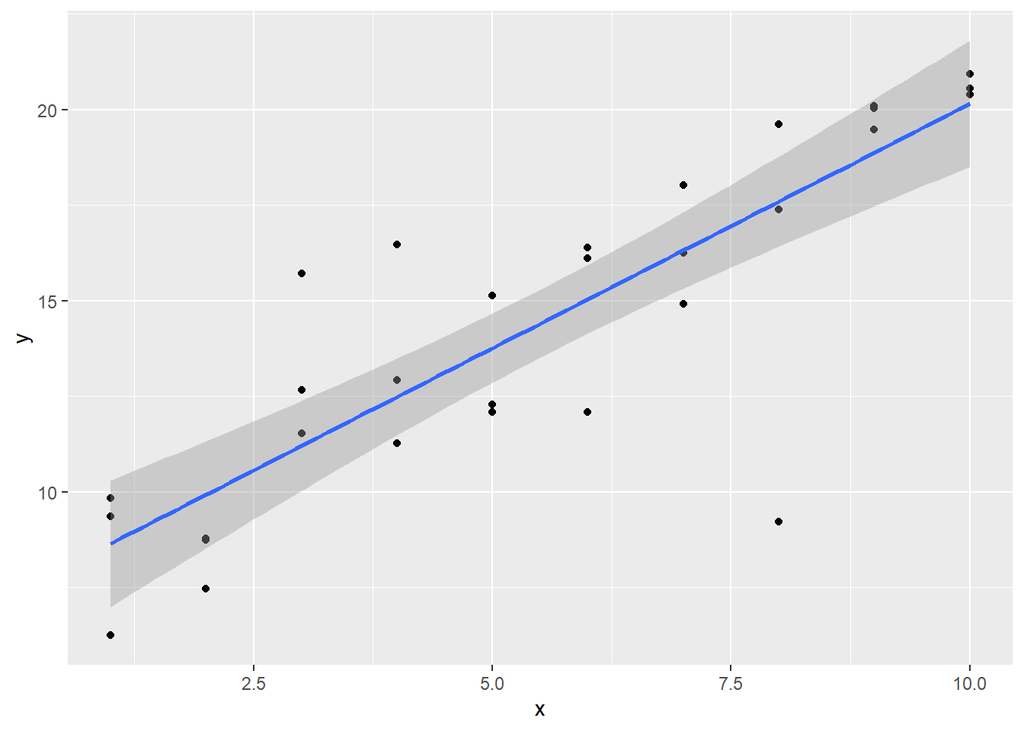

```r
sim1a <- tibble(
  x = rep(1:10, each = 3),
  y = x * 1.5 + 6 + rt(length(x), df = 2)
)

#model <- lm(y ~ x, data = sim1a)

ggplot(sim1a, aes(x = x, y = y)) +
  geom_point() +
  geom_smooth(method = "lm")
```

okay I know I’m supposed to say that the oultiers are pulling the line in a direction. But honestly it doesn’t look like its moving that much. Like I can tell it shifts a little, but that makes sense since the points are so far away.

## Exercise 2

```r
measure_distance <- function(coefficients, data) {
  predicted <- data$x * coefficients[1] + coefficients[2]
  diff <- data$y - predicted
  mean_abs_dist <- mean(abs(diff))
  return(mean_abs_dist)
}

sim1a <- tibble(
  x = rep(1:10, each = 3),
  y = x * 1.5 + 6 + rt(length(x), df = 2)
)

fit_optim <- optim(
  c(1, 1),
  measure_distance,
  data = sim1a,
  method = "Nelder-Mead"
)

coefficients_optim <- fit_optim$par
print(coefficients_optim)
```

```
## [1] 1.376287 6.654747
```

```r
fit_lm <- lm(y ~ x, data = sim1a)
print(coef(fit_lm))
```

```
## (Intercept)           x
##    5.611256    1.547876
```

You can see the results are flipped and consistently slightly different (slightly is not a super clear signifier but you get it)